# Lab 9

Desiree Smith

11/9/2021

### Question 1

State the null hypothesis of the Chi-square test.

The null hypothesis of the chi- square test is that there is no significant relationship for the data.

### Question 2

Consider the results of your test and explain whether you think that Brown Creepers show a significant habitat preference.

Based on the results of test you can see that the brown creepers do show significant a significant relationship. The p-value is very small so we will reject the null.

```r
owls = matrix(c(16, 9, 4, 11), nrow=2)
rownames(owls) = c("present", "absent")
colnames(owls) = c("old", "young")
chisq.test(br_creeper_table)
```

```
##
##  Pearson's Chi-squared test with Yates' continuity correction
##
## data:  br_creeper_table
## X-squared = 23.3, df = 1, p-value = 1.386e-06
```

### Question 3 -5

```r
require(palmerpenguins)
penguins
```

```
## # A tibble: 344 × 8
##    species island    bill_length_mm bill_depth_mm flipper_length_mm body_mass_g
##    <fct>   <fct>              <dbl>         <dbl>             <int>       <int>
##  1 Adelie  Torgersen           39.1          18.7               181        3750
##  2 Adelie  Torgersen           39.5          17.4               186        3800
##  3 Adelie  Torgersen           40.3          18                 195        3250
##  4 Adelie  Torgersen           NA            NA                  NA          NA
##  5 Adelie  Torgersen           36.7          19.3               193        3450
##  6 Adelie  Torgersen           39.3          20.6               190        3650
##  7 Adelie  Torgersen           38.9          17.8               181        3625
##  8 Adelie  Torgersen           39.2          19.6               195        4675
##  9 Adelie  Torgersen           34.1          18.1               193        3475
## 10 Adelie  Torgersen           42            20.2               190        4250
## # … with 334 more rows, and 2 more variables: sex <fct>, year <int>
```

```r
fit_species =
  lm( formula = body_mass_g
    ~ species,
    data = penguins)
fit_species
```

```
##
## Call:
## lm(formula = body_mass_g ~ species, data = penguins)
##
## Coefficients:
##      (Intercept)  speciesChinstrap     speciesGentoo
##          3700.66             32.43           1375.35
```

```r
fit_sex =
  lm(
    formula = body_mass_g ~ sex,
    data = penguins)
fit_sex
```

```
##
## Call:
## lm(formula = body_mass_g ~ sex, data = penguins)
##
## Coefficients:
## (Intercept)      sexmale
##      3862.3        683.4
```

```r
fit_both =
  lm(
    formula = body_mass_g ~ sex * species,
    data = penguins)
fit_both
```

```
##
## Call:
## lm(formula = body_mass_g ~ sex * species, data = penguins)
##
## Coefficients:
##              (Intercept)                   sexmale          speciesChinstrap
##                   3368.8                     674.7                     158.4
##            speciesGentoo  sexmale:speciesChinstrap     sexmale:speciesGentoo
##                   1310.9                    -262.9                     130.4
```

### Question 6

Include a conditional boxplot corresponding to your fit_species model.

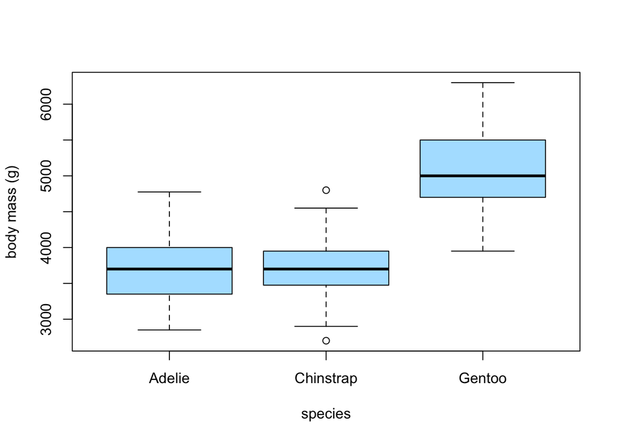

```r
boxplot(body_mass_g ~ species,
    data = penguins, ylab = "body mass (g)",col= "lightskyblue1"

             )
```

### Question 7

Include a conditional boxplot corresponding to your fit_sex model.

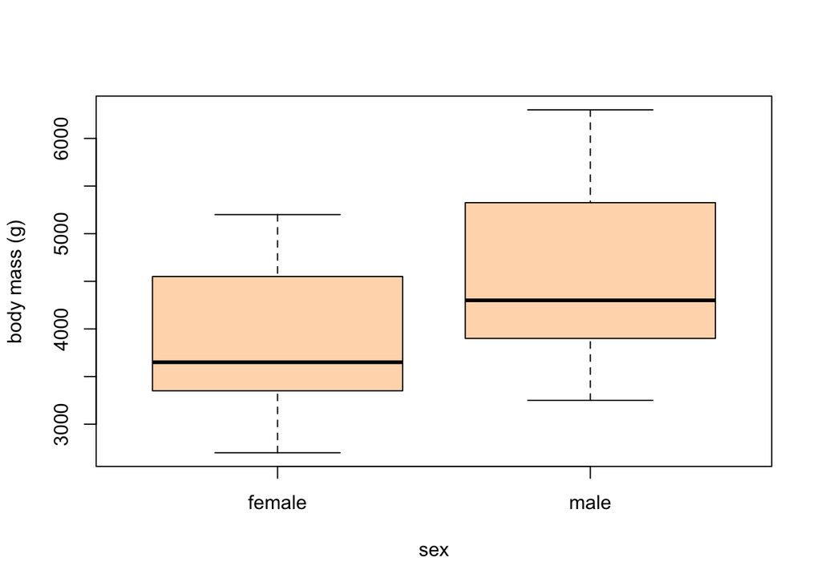

```r
boxplot(body_mass_g ~ sex,
    data = penguins, ylab = "body mass (g)",col= "peachpuff1")
```

### Question 8

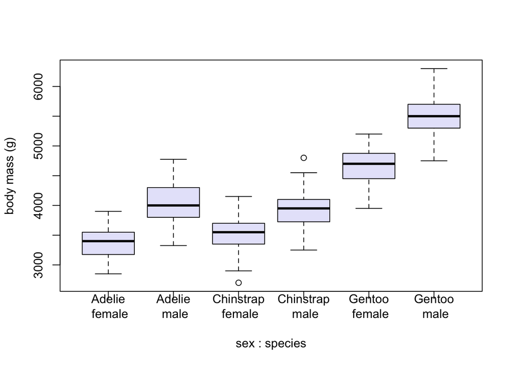

```r
#Example
boxplot(body_mass_g ~ sex * species,
    data = penguins, ylab = "body mass (g)",col= "lavender",
   names = c("Adelie\n female",
             "Adelie\n male",
             "Chinstrap\n female",
             "Chinstrap\n male",
             "Gentoo\n female",
             "Gentoo\n male"

             ))
```

### Question 9

Based on the shapes of the boxes, which of the models (if any) do you think may have problems fulfilling the heterogeneity assumption?

The model that includes penguin body mass of species does not fulfill the heterogeneity assumption. The shapes of the boxes vary the most out of all of the models.

### Question 10

State the null hypothesis of the Bartlett test.

The Null hypothesis of the Bartlett test is that the all of the variances are equal to each other.

### Question 11

What was the p-value from the Bartlett test of homogeneity for observations grouped by species?

The p-value for the test is 0.050.

```r
bartlett.test(body_mass_g ~ species, data= penguins)
```

```
##
##  Bartlett test of homogeneity of variances
##
## data:  body_mass_g by species
## Bartlett's K-squared = 5.9895, df = 2, p-value = 0.05005
```

### Question 12

What was the p-value from the Bartlett test of homogeneity for observations grouped by sex?

The p-value is 0.032.

```r
bartlett.test(body_mass_g ~ sex, data= penguins)
```

```
##
##  Bartlett test of homogeneity of variances
##
## data:  body_mass_g by sex
## Bartlett's K-squared = 4.6017, df = 1, p-value = 0.03194
```

### Question 13

What was the p-value from the Bartlett test of homogeneity for observations grouped by both factors?

The p-value of Bartlett test 0.1741. It is not very significant.

```r
dat_groups = aggregate(
  body_mass_g ~ species * sex,
  data = penguins,
  FUN = c)
str(dat_groups)
```

```
## 'data.frame':    6 obs. of  3 variables:
##  $ species    : Factor w/ 3 levels "Adelie","Chinstrap",..: 1 2 3 1 2 3
##  $ sex        : Factor w/ 2 levels "female","male": 1 1 1 2 2 2
##  $ body_mass_g:List of 6
##   ..$ : int  3800 3250 3450 3625 3200 3700 3450 3325 3400 3800 ...
##   ..$ : int  3500 3525 3950 3250 4150 3800 3700 3575 3700 3450 ...
##   ..$ : int  4500 4450 4550 4800 4400 4650 4650 4200 4150 4800 ...
##   ..$ : int  3750 3650 4675 3800 4400 4500 4200 3600 3950 3800 ...
##   ..$ : int  3900 3650 3725 3750 3700 3775 4050 4050 3300 4400 ...
##   ..$ : int  5700 5700 5400 5200 5150 5550 5850 5850 6300 5350 ...
```

```r
bartlett.test(dat_groups$body_mass_g
)
```

```
##
##  Bartlett test of homogeneity of variances
##
## data:  dat_groups$body_mass_g
## Bartlett's K-squared = 7.6908, df = 5, p-value = 0.1741
```

### Question 14

Based on the results of the Bartlett tests, do you anticipate any issues with heterogeneity in any of the models? Make sure you justify your response with the results of your tests.